# Risk Factor Analysis

## Outcome Variable

**Outcome Variable:** stunted

## Predictor Variables

**Intervention Variable:** hhwealth_quart

**Adjustment Set:**

unadjusted

## Stratifying Variables

The analysis was stratified on these variable(s):

- agecat
- studyid
- country

## Data Summary

| agecat | studyid | country | hhwealth_quart | stunted | n_cell | n |
| --- | --- | --- | --- | --- | --- | --- |
| Birth | ki0047075b-MAL-ED | BANGLADESH | Wealth Q4 | 0 | 23 | 82 |
| Birth | ki0047075b-MAL-ED | BANGLADESH | Wealth Q4 | 1 | 3 | 82 |
| Birth | ki0047075b-MAL-ED | BANGLADESH | Wealth Q1 | 0 | 3 | 82 |
| Birth | ki0047075b-MAL-ED | BANGLADESH | Wealth Q1 | 1 | 1 | 82 |
| Birth | ki0047075b-MAL-ED | BANGLADESH | Wealth Q2 | 0 | 13 | 82 |
| Birth | ki0047075b-MAL-ED | BANGLADESH | Wealth Q2 | 1 | 2 | 82 |
| Birth | ki0047075b-MAL-ED | BANGLADESH | Wealth Q3 | 0 | 27 | 82 |
| Birth | ki0047075b-MAL-ED | BANGLADESH | Wealth Q3 | 1 | 10 | 82 |
| 6 months | ki0047075b-MAL-ED | BANGLADESH | Wealth Q4 | 0 | 24 | 81 |
| 6 months | ki0047075b-MAL-ED | BANGLADESH | Wealth Q4 | 1 | 2 | 81 |
| 6 months | ki0047075b-MAL-ED | BANGLADESH | Wealth Q1 | 0 | 3 | 81 |
| 6 months | ki0047075b-MAL-ED | BANGLADESH | Wealth Q1 | 1 | 1 | 81 |
| 6 months | ki0047075b-MAL-ED | BANGLADESH | Wealth Q2 | 0 | 11 | 81 |
| 6 months | ki0047075b-MAL-ED | BANGLADESH | Wealth Q2 | 1 | 4 | 81 |
| 6 months | ki0047075b-MAL-ED | BANGLADESH | Wealth Q3 | 0 | 27 | 81 |
| 6 months | ki0047075b-MAL-ED | BANGLADESH | Wealth Q3 | 1 | 9 | 81 |
| 24 months | ki0047075b-MAL-ED | BANGLADESH | Wealth Q4 | 0 | 15 | 77 |
| 24 months | ki0047075b-MAL-ED | BANGLADESH | Wealth Q4 | 1 | 11 | 77 |
| 24 months | ki0047075b-MAL-ED | BANGLADESH | Wealth Q1 | 0 | 1 | 77 |
| 24 months | ki0047075b-MAL-ED | BANGLADESH | Wealth Q1 | 1 | 3 | 77 |
| 24 months | ki0047075b-MAL-ED | BANGLADESH | Wealth Q2 | 0 | 8 | 77 |
| 24 months | ki0047075b-MAL-ED | BANGLADESH | Wealth Q2 | 1 | 7 | 77 |
| 24 months | ki0047075b-MAL-ED | BANGLADESH | Wealth Q3 | 0 | 16 | 77 |
| 24 months | ki0047075b-MAL-ED | BANGLADESH | Wealth Q3 | 1 | 16 | 77 |
| Birth | ki0047075b-MAL-ED | BRAZIL | Wealth Q4 | 0 | 1 | 3 |
| Birth | ki0047075b-MAL-ED | BRAZIL | Wealth Q4 | 1 | 1 | 3 |
| Birth | ki0047075b-MAL-ED | BRAZIL | Wealth Q2 | 0 | 0 | 3 |
| Birth | ki0047075b-MAL-ED | BRAZIL | Wealth Q2 | 1 | 1 | 3 |
| 6 months | ki0047075b-MAL-ED | BRAZIL | Wealth Q4 | 0 | 2 | 3 |
| 6 months | ki0047075b-MAL-ED | BRAZIL | Wealth Q2 | 0 | 1 | 3 |

[output cut: 334 more lines]

The following strata were considered:

- agecat: 24 months, studyid: ki0047075b-MAL-ED, country: BANGLADESH
- agecat: 24 months, studyid: ki0047075b-MAL-ED, country: BRAZIL
- agecat: 24 months, studyid: ki0047075b-MAL-ED, country: INDIA
- agecat: 24 months, studyid: ki0047075b-MAL-ED, country: NEPAL
- agecat: 24 months, studyid: ki0047075b-MAL-ED, country: PERU
- agecat: 24 months, studyid: ki0047075b-MAL-ED, country: SOUTH AFRICA
- agecat: 24 months, studyid: ki0047075b-MAL-ED, country: TANZANIA, UNITED REPUBLIC OF
- agecat: 24 months, studyid: ki1000108-CMC-V-BCS-2002, country: INDIA
- agecat: 24 months, studyid: ki1000108-IRC, country: INDIA
- agecat: 24 months, studyid: ki1017093b-PROVIDE, country: BANGLADESH
- agecat: 24 months, studyid: ki1066203-TanzaniaChild2, country: TANZANIA, UNITED REPUBLIC OF
- agecat: 24 months, studyid: ki1113344-GMS-Nepal, country: NEPAL
- agecat: 24 months, studyid: ki1114097-CONTENT, country: PERU
- agecat: 24 months, studyid: ki1135781-COHORTS, country: GUATEMALA
- agecat: 24 months, studyid: ki1135781-COHORTS, country: PHILIPPINES
- agecat: 24 months, studyid: ki1148112-LCNI-5, country: MALAWI
- agecat: 24 months, studyid: kiGH5241-JiVitA-3, country: BANGLADESH
- agecat: 24 months, studyid: kiGH5241-JiVitA-4, country: BANGLADESH
- agecat: 6 months, studyid: ki0047075b-MAL-ED, country: BANGLADESH
- agecat: 6 months, studyid: ki0047075b-MAL-ED, country: BRAZIL
- agecat: 6 months, studyid: ki0047075b-MAL-ED, country: INDIA
- agecat: 6 months, studyid: ki0047075b-MAL-ED, country: NEPAL
- agecat: 6 months, studyid: ki0047075b-MAL-ED, country: PERU
- agecat: 6 months, studyid: ki0047075b-MAL-ED, country: SOUTH AFRICA
- agecat: 6 months, studyid: ki0047075b-MAL-ED, country: TANZANIA, UNITED REPUBLIC OF
- agecat: 6 months, studyid: ki1000108-CMC-V-BCS-2002, country: INDIA
- agecat: 6 months, studyid: ki1000108-IRC, country: INDIA
- agecat: 6 months, studyid: ki1017093b-PROVIDE, country: BANGLADESH
- agecat: 6 months, studyid: ki1066203-TanzaniaChild2, country: TANZANIA, UNITED REPUBLIC OF
- agecat: 6 months, studyid: ki1113344-GMS-Nepal, country: NEPAL
- agecat: 6 months, studyid: ki1114097-CONTENT, country: PERU
- agecat: 6 months, studyid: ki1135781-COHORTS, country: GUATEMALA
- agecat: 6 months, studyid: ki1135781-COHORTS, country: PHILIPPINES
- agecat: 6 months, studyid: ki1148112-LCNI-5, country: MALAWI
- agecat: 6 months, studyid: kiGH5241-JiVitA-3, country: BANGLADESH
- agecat: 6 months, studyid: kiGH5241-JiVitA-4, country: BANGLADESH
- agecat: Birth, studyid: ki0047075b-MAL-ED, country: BANGLADESH
- agecat: Birth, studyid: ki0047075b-MAL-ED, country: BRAZIL
- agecat: Birth, studyid: ki0047075b-MAL-ED, country: INDIA
- agecat: Birth, studyid: ki0047075b-MAL-ED, country: NEPAL
- agecat: Birth, studyid: ki0047075b-MAL-ED, country: PERU
- agecat: Birth, studyid: ki0047075b-MAL-ED, country: SOUTH AFRICA
- agecat: Birth, studyid: ki0047075b-MAL-ED, country: TANZANIA, UNITED REPUBLIC OF
- agecat: Birth, studyid: ki1000108-CMC-V-BCS-2002, country: INDIA
- agecat: Birth, studyid: ki1000108-IRC, country: INDIA
- agecat: Birth, studyid: ki1114097-CONTENT, country: PERU
- agecat: Birth, studyid: ki1135781-COHORTS, country: GUATEMALA
- agecat: Birth, studyid: ki1135781-COHORTS, country: PHILIPPINES
- agecat: Birth, studyid: kiGH5241-JiVitA-3, country: BANGLADESH
- agecat: Birth, studyid: kiGH5241-JiVitA-4, country: BANGLADESH

### Dropped Strata

Some strata were dropped due to rare outcomes:

- agecat: Birth, studyid: ki0047075b-MAL-ED, country: BANGLADESH
- agecat: 6 months, studyid: ki0047075b-MAL-ED, country: BANGLADESH
- agecat: 24 months, studyid: ki0047075b-MAL-ED, country: BANGLADESH
- agecat: Birth, studyid: ki0047075b-MAL-ED, country: BRAZIL
- agecat: 6 months, studyid: ki0047075b-MAL-ED, country: BRAZIL
- agecat: 24 months, studyid: ki0047075b-MAL-ED, country: BRAZIL
- agecat: Birth, studyid: ki0047075b-MAL-ED, country: INDIA
- agecat: 6 months, studyid: ki0047075b-MAL-ED, country: INDIA
- agecat: 24 months, studyid: ki0047075b-MAL-ED, country: INDIA
- agecat: Birth, studyid: ki0047075b-MAL-ED, country: NEPAL
- agecat: 6 months, studyid: ki0047075b-MAL-ED, country: NEPAL
- agecat: 24 months, studyid: ki0047075b-MAL-ED, country: NEPAL
- agecat: Birth, studyid: ki0047075b-MAL-ED, country: PERU
- agecat: 6 months, studyid: ki0047075b-MAL-ED, country: PERU
- agecat: 24 months, studyid: ki0047075b-MAL-ED, country: PERU
- agecat: Birth, studyid: ki0047075b-MAL-ED, country: SOUTH AFRICA
- agecat: 6 months, studyid: ki0047075b-MAL-ED, country: SOUTH AFRICA
- agecat: 24 months, studyid: ki0047075b-MAL-ED, country: SOUTH AFRICA
- agecat: Birth, studyid: ki0047075b-MAL-ED, country: TANZANIA, UNITED REPUBLIC OF
- agecat: 6 months, studyid: ki0047075b-MAL-ED, country: TANZANIA, UNITED REPUBLIC OF
- agecat: 24 months, studyid: ki0047075b-MAL-ED, country: TANZANIA, UNITED REPUBLIC OF
- agecat: Birth, studyid: ki1000108-CMC-V-BCS-2002, country: INDIA
- agecat: 24 months, studyid: ki1066203-TanzaniaChild2, country: TANZANIA, UNITED REPUBLIC OF
- agecat: 6 months, studyid: ki1114097-CONTENT, country: PERU
- agecat: 24 months, studyid: ki1114097-CONTENT, country: PERU
- agecat: Birth, studyid: ki1114097-CONTENT, country: PERU

## Methods Detail

We’re interested in the causal parameters $E[Y_a]$ for all values of $a \in \mathcal{A}$. These parameters represent the mean outcome if, possibly contrary to fact, we intervened to set all units to have $A=a$. Under the randomization and positivity assumptions, these are identified by the statistical parameters $\psi_a=E_W[E_{Y|A,W}(Y|A=a,W)]$. In addition, we’re interested in the mean of $Y$, $E[Y]$ under no intervention (the observed mean). We will estimate these parameters by using SuperLearner to fit the relevant likelihood factors – $E_{Y|A,W}(Y|A=a,W)$ and $p(A=a|W)$, and then updating our likelihood fit using a joint TMLE.

For unadjusted analyses ($W=\{\}$), initial likelihoods were estimated using Lrnr_glm to estimate the simple $E(Y|A)$ and Lrnr_mean to estimate $p(A)$. For adjusted analyses, a small library containing Lrnr_glmnet, Lrnr_xgboost, and Lrnr_mean was used.

Having estimated these parameters, we will then use the delta method to estimate relative risks and attributable risks relative to a prespecified baseline level of $A$.

# Results Detail

## Results Plots

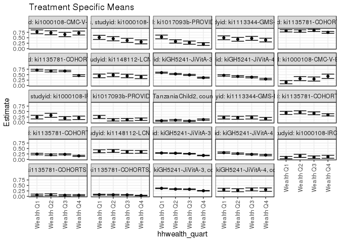

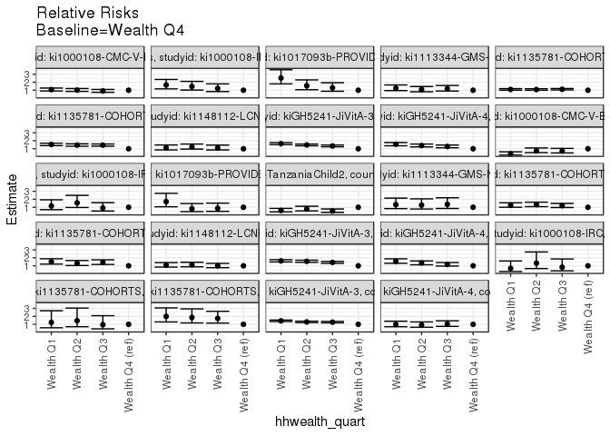

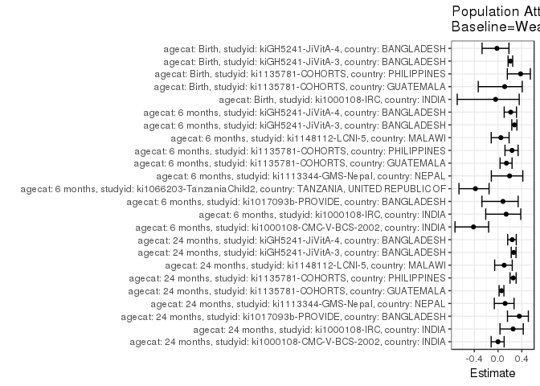

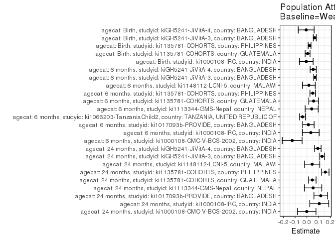

## Results Table

### Parameter: TSM

| agecat | studyid | country | intervention_level | baseline_level | estimate | ci_lower | ci_upper |
| --- | --- | --- | --- | --- | --- | --- | --- |
| Birth | ki1000108-IRC | INDIA | Wealth Q4 | NA | 0.1208791 | 0.0538154 | 0.1879429 |
| Birth | ki1000108-IRC | INDIA | Wealth Q1 | NA | 0.0816327 | 0.0273532 | 0.1359121 |
| Birth | ki1000108-IRC | INDIA | Wealth Q2 | NA | 0.1616162 | 0.0890131 | 0.2342192 |
| Birth | ki1000108-IRC | INDIA | Wealth Q3 | NA | 0.1000000 | 0.0411252 | 0.1588748 |
| Birth | ki1135781-COHORTS | GUATEMALA | Wealth Q4 | NA | 0.0511945 | 0.0259434 | 0.0764457 |
| Birth | ki1135781-COHORTS | GUATEMALA | Wealth Q1 | NA | 0.0636943 | 0.0254714 | 0.1019172 |
| Birth | ki1135781-COHORTS | GUATEMALA | Wealth Q2 | NA | 0.0745342 | 0.0339404 | 0.1151279 |
| Birth | ki1135781-COHORTS | GUATEMALA | Wealth Q3 | NA | 0.0487805 | 0.0192751 | 0.0782858 |
| Birth | ki1135781-COHORTS | PHILIPPINES | Wealth Q4 | NA | 0.0380048 | 0.0250875 | 0.0509220 |
| Birth | ki1135781-COHORTS | PHILIPPINES | Wealth Q1 | NA | 0.0756914 | 0.0559093 | 0.0954735 |
| Birth | ki1135781-COHORTS | PHILIPPINES | Wealth Q2 | NA | 0.0706320 | 0.0489787 | 0.0922852 |
| Birth | ki1135781-COHORTS | PHILIPPINES | Wealth Q3 | NA | 0.0661914 | 0.0506392 | 0.0817437 |
| Birth | kiGH5241-JiVitA-3 | BANGLADESH | Wealth Q4 | NA | 0.2558420 | 0.2416437 | 0.2700403 |
| Birth | kiGH5241-JiVitA-3 | BANGLADESH | Wealth Q1 | NA | 0.3671665 | 0.3526978 | 0.3816352 |
| Birth | kiGH5241-JiVitA-3 | BANGLADESH | Wealth Q2 | NA | 0.3322110 | 0.3181407 | 0.3462813 |
| Birth | kiGH5241-JiVitA-3 | BANGLADESH | Wealth Q3 | NA | 0.3242084 | 0.3100327 | 0.3383841 |
| Birth | kiGH5241-JiVitA-4 | BANGLADESH | Wealth Q4 | NA | 0.3060109 | 0.2278929 | 0.3841289 |
| Birth | kiGH5241-JiVitA-4 | BANGLADESH | Wealth Q1 | NA | 0.3014354 | 0.2328109 | 0.3700599 |
| Birth | kiGH5241-JiVitA-4 | BANGLADESH | Wealth Q2 | NA | 0.2785388 | 0.2086803 | 0.3483973 |
| Birth | kiGH5241-JiVitA-4 | BANGLADESH | Wealth Q3 | NA | 0.3175355 | 0.2503811 | 0.3846900 |
| 6 months | ki1000108-CMC-V-BCS-2002 | INDIA | Wealth Q4 | NA | 0.4255319 | 0.3254461 | 0.5256177 |
| 6 months | ki1000108-CMC-V-BCS-2002 | INDIA | Wealth Q1 | NA | 0.1538462 | 0.0796153 | 0.2280770 |
| 6 months | ki1000108-CMC-V-BCS-2002 | INDIA | Wealth Q2 | NA | 0.3191489 | 0.2247871 | 0.4135107 |
| 6 months | ki1000108-CMC-V-BCS-2002 | INDIA | Wealth Q3 | NA | 0.3000000 | 0.2051962 | 0.3948038 |
| 6 months | ki1000108-IRC | INDIA | Wealth Q4 | NA | 0.2121212 | 0.1314931 | 0.2927493 |
| 6 months | ki1000108-IRC | INDIA | Wealth Q1 | NA | 0.2476190 | 0.1649584 | 0.3302796 |
| 6 months | ki1000108-IRC | INDIA | Wealth Q2 | NA | 0.3300000 | 0.2377266 | 0.4222734 |
| 6 months | ki1000108-IRC | INDIA | Wealth Q3 | NA | 0.1941748 | 0.1176890 | 0.2706605 |
| 6 months | ki1017093b-PROVIDE | BANGLADESH | Wealth Q4 | NA | 0.1483871 | 0.0923758 | 0.2043984 |
| 6 months | ki1017093b-PROVIDE | BANGLADESH | Wealth Q1 | NA | 0.2536232 | 0.1809698 | 0.3262766 |

[output cut: 66 more lines]

### Parameter: E(Y)

| agecat | studyid | country | intervention_level | baseline_level | estimate | ci_lower | ci_upper |
| --- | --- | --- | --- | --- | --- | --- | --- |
| Birth | ki1000108-IRC | INDIA | NA | NA | 0.1159794 | 0.0840777 | 0.1478811 |
| Birth | ki1135781-COHORTS | GUATEMALA | NA | NA | 0.0575980 | 0.0416028 | 0.0735933 |
| Birth | ki1135781-COHORTS | PHILIPPINES | NA | NA | 0.0613316 | 0.0528136 | 0.0698496 |
| Birth | kiGH5241-JiVitA-3 | BANGLADESH | NA | NA | 0.3233133 | 0.3156536 | 0.3309730 |
| Birth | kiGH5241-JiVitA-4 | BANGLADESH | NA | NA | 0.3004866 | 0.2649179 | 0.3360553 |
| 6 months | ki1000108-CMC-V-BCS-2002 | INDIA | NA | NA | 0.3008130 | 0.2539566 | 0.3476694 |
| 6 months | ki1000108-IRC | INDIA | NA | NA | 0.2457002 | 0.2038248 | 0.2875757 |
| 6 months | ki1017093b-PROVIDE | BANGLADESH | NA | NA | 0.1617900 | 0.1318200 | 0.1917600 |
| 6 months | ki1066203-TanzaniaChild2 | TANZANIA, UNITED REPUBLIC OF | NA | NA | 0.0965347 | 0.0836528 | 0.1094165 |
| 6 months | ki1113344-GMS-Nepal | NEPAL | NA | NA | 0.2113677 | 0.1776128 | 0.2451225 |
| 6 months | ki1135781-COHORTS | GUATEMALA | NA | NA | 0.4086486 | 0.3769522 | 0.4403450 |
| 6 months | ki1135781-COHORTS | PHILIPPINES | NA | NA | 0.2112260 | 0.1958496 | 0.2266024 |
| 6 months | ki1148112-LCNI-5 | MALAWI | NA | NA | 0.3627451 | 0.3297365 | 0.3957537 |
| 6 months | kiGH5241-JiVitA-3 | BANGLADESH | NA | NA | 0.2513837 | 0.2432545 | 0.2595129 |
| 6 months | kiGH5241-JiVitA-4 | BANGLADESH | NA | NA | 0.2522280 | 0.2381653 | 0.2662906 |
| 24 months | ki1000108-CMC-V-BCS-2002 | INDIA | NA | NA | 0.7150538 | 0.6691221 | 0.7609854 |
| 24 months | ki1000108-IRC | INDIA | NA | NA | 0.4156479 | 0.3678270 | 0.4634689 |
| 24 months | ki1017093b-PROVIDE | BANGLADESH | NA | NA | 0.3298611 | 0.2914318 | 0.3682904 |
| 24 months | ki1113344-GMS-Nepal | NEPAL | NA | NA | 0.4468938 | 0.4032281 | 0.4905594 |
| 24 months | ki1135781-COHORTS | GUATEMALA | NA | NA | 0.7909441 | 0.7661948 | 0.8156934 |
| 24 months | ki1135781-COHORTS | PHILIPPINES | NA | NA | 0.6167689 | 0.5974942 | 0.6360437 |
| 24 months | ki1148112-LCNI-5 | MALAWI | NA | NA | 0.4390244 | 0.3983906 | 0.4796582 |
| 24 months | kiGH5241-JiVitA-3 | BANGLADESH | NA | NA | 0.4907805 | 0.4776507 | 0.5039102 |
| 24 months | kiGH5241-JiVitA-4 | BANGLADESH | NA | NA | 0.3922477 | 0.3752571 | 0.4092384 |

### Parameter: RR

| agecat | studyid | country | intervention_level | baseline_level | estimate | ci_lower | ci_upper |
| --- | --- | --- | --- | --- | --- | --- | --- |
| Birth | ki1000108-IRC | INDIA | Wealth Q4 | Wealth Q4 | 1.0000000 | 1.0000000 | 1.0000000 |
| Birth | ki1000108-IRC | INDIA | Wealth Q1 | Wealth Q4 | 0.6753247 | 0.2840672 | 1.6054774 |
| Birth | ki1000108-IRC | INDIA | Wealth Q2 | Wealth Q4 | 1.3370064 | 0.6547919 | 2.7300066 |
| Birth | ki1000108-IRC | INDIA | Wealth Q3 | Wealth Q4 | 0.8272727 | 0.3683993 | 1.8577130 |
| Birth | ki1135781-COHORTS | GUATEMALA | Wealth Q4 | Wealth Q4 | 1.0000000 | 1.0000000 | 1.0000000 |
| Birth | ki1135781-COHORTS | GUATEMALA | Wealth Q1 | Wealth Q4 | 1.2441614 | 0.5721643 | 2.7054073 |
| Birth | ki1135781-COHORTS | GUATEMALA | Wealth Q2 | Wealth Q4 | 1.4559006 | 0.6982621 | 3.0356032 |
| Birth | ki1135781-COHORTS | GUATEMALA | Wealth Q3 | Wealth Q4 | 0.9528455 | 0.4365830 | 2.0795921 |
| Birth | ki1135781-COHORTS | PHILIPPINES | Wealth Q4 | Wealth Q4 | 1.0000000 | 1.0000000 | 1.0000000 |
| Birth | ki1135781-COHORTS | PHILIPPINES | Wealth Q1 | Wealth Q4 | 1.9916303 | 1.2971947 | 3.0578225 |
| Birth | ki1135781-COHORTS | PHILIPPINES | Wealth Q2 | Wealth Q4 | 1.8585037 | 1.1759273 | 2.9372872 |
| Birth | ki1135781-COHORTS | PHILIPPINES | Wealth Q3 | Wealth Q4 | 1.7416624 | 1.1521723 | 2.6327556 |
| Birth | kiGH5241-JiVitA-3 | BANGLADESH | Wealth Q4 | Wealth Q4 | 1.0000000 | 1.0000000 | 1.0000000 |
| Birth | kiGH5241-JiVitA-3 | BANGLADESH | Wealth Q1 | Wealth Q4 | 1.4351300 | 1.3429126 | 1.5336799 |
| Birth | kiGH5241-JiVitA-3 | BANGLADESH | Wealth Q2 | Wealth Q4 | 1.2985008 | 1.2139340 | 1.3889588 |
| Birth | kiGH5241-JiVitA-3 | BANGLADESH | Wealth Q3 | Wealth Q4 | 1.2672213 | 1.1828685 | 1.3575894 |
| Birth | kiGH5241-JiVitA-4 | BANGLADESH | Wealth Q4 | Wealth Q4 | 1.0000000 | 1.0000000 | 1.0000000 |
| Birth | kiGH5241-JiVitA-4 | BANGLADESH | Wealth Q1 | Wealth Q4 | 0.9850478 | 0.7001632 | 1.3858473 |
| Birth | kiGH5241-JiVitA-4 | BANGLADESH | Wealth Q2 | Wealth Q4 | 0.9102250 | 0.6372081 | 1.3002182 |
| Birth | kiGH5241-JiVitA-4 | BANGLADESH | Wealth Q3 | Wealth Q4 | 1.0376608 | 0.7471703 | 1.4410903 |
| 6 months | ki1000108-CMC-V-BCS-2002 | INDIA | Wealth Q4 | Wealth Q4 | 1.0000000 | 1.0000000 | 1.0000000 |
| 6 months | ki1000108-CMC-V-BCS-2002 | INDIA | Wealth Q1 | Wealth Q4 | 0.3615385 | 0.2113666 | 0.6184046 |
| 6 months | ki1000108-CMC-V-BCS-2002 | INDIA | Wealth Q2 | Wealth Q4 | 0.7500000 | 0.5140216 | 1.0943119 |
| 6 months | ki1000108-CMC-V-BCS-2002 | INDIA | Wealth Q3 | Wealth Q4 | 0.7050000 | 0.4754511 | 1.0453757 |
| 6 months | ki1000108-IRC | INDIA | Wealth Q4 | Wealth Q4 | 1.0000000 | 1.0000000 | 1.0000000 |
| 6 months | ki1000108-IRC | INDIA | Wealth Q1 | Wealth Q4 | 1.1673469 | 0.7038798 | 1.9359824 |
| 6 months | ki1000108-IRC | INDIA | Wealth Q2 | Wealth Q4 | 1.5557143 | 0.9705053 | 2.4938009 |
| 6 months | ki1000108-IRC | INDIA | Wealth Q3 | Wealth Q4 | 0.9153953 | 0.5295166 | 1.5824783 |
| 6 months | ki1017093b-PROVIDE | BANGLADESH | Wealth Q4 | Wealth Q4 | 1.0000000 | 1.0000000 | 1.0000000 |
| 6 months | ki1017093b-PROVIDE | BANGLADESH | Wealth Q1 | Wealth Q4 | 1.7091997 | 1.0641395 | 2.7452827 |

[output cut: 66 more lines]

### Parameter: PAR

| agecat | studyid | country | intervention_level | baseline_level | estimate | ci_lower | ci_upper |
| --- | --- | --- | --- | --- | --- | --- | --- |
| Birth | ki1000108-IRC | INDIA | Wealth Q4 | NA | -0.0048997 | -0.0632572 | 0.0534577 |
| Birth | ki1135781-COHORTS | GUATEMALA | Wealth Q4 | NA | 0.0064035 | -0.0144668 | 0.0272738 |
| Birth | ki1135781-COHORTS | PHILIPPINES | Wealth Q4 | NA | 0.0233268 | 0.0111920 | 0.0354617 |
| Birth | kiGH5241-JiVitA-3 | BANGLADESH | Wealth Q4 | NA | 0.0674713 | 0.0549926 | 0.0799500 |
| Birth | kiGH5241-JiVitA-4 | BANGLADESH | Wealth Q4 | NA | -0.0055243 | -0.0731080 | 0.0620594 |
| 6 months | ki1000108-CMC-V-BCS-2002 | INDIA | Wealth Q4 | NA | -0.1247189 | -0.2090344 | -0.0404035 |
| 6 months | ki1000108-IRC | INDIA | Wealth Q4 | NA | 0.0335790 | -0.0377782 | 0.1049362 |
| 6 months | ki1017093b-PROVIDE | BANGLADESH | Wealth Q4 | NA | 0.0134029 | -0.0351927 | 0.0619986 |
| 6 months | ki1066203-TanzaniaChild2 | TANZANIA, UNITED REPUBLIC OF | Wealth Q4 | NA | -0.0369315 | -0.0616559 | -0.0122071 |
| 6 months | ki1113344-GMS-Nepal | NEPAL | Wealth Q4 | NA | 0.0411549 | -0.0141930 | 0.0965029 |
| 6 months | ki1135781-COHORTS | GUATEMALA | Wealth Q4 | NA | 0.0576162 | 0.0164491 | 0.0987833 |
| 6 months | ki1135781-COHORTS | PHILIPPINES | Wealth Q4 | NA | 0.0497186 | 0.0262132 | 0.0732240 |
| 6 months | ki1148112-LCNI-5 | MALAWI | Wealth Q4 | NA | 0.0171230 | -0.0373396 | 0.0715855 |
| 6 months | kiGH5241-JiVitA-3 | BANGLADESH | Wealth Q4 | NA | 0.0693930 | 0.0585163 | 0.0802696 |
| 6 months | kiGH5241-JiVitA-4 | BANGLADESH | Wealth Q4 | NA | 0.0539824 | 0.0279587 | 0.0800061 |
| 24 months | ki1000108-CMC-V-BCS-2002 | INDIA | Wealth Q4 | NA | -0.0007357 | -0.0791270 | 0.0776556 |
| 24 months | ki1000108-IRC | INDIA | Wealth Q4 | NA | 0.1056479 | 0.0250503 | 0.1862456 |
| 24 months | ki1017093b-PROVIDE | BANGLADESH | Wealth Q4 | NA | 0.1183226 | 0.0603353 | 0.1763100 |
| 24 months | ki1113344-GMS-Nepal | NEPAL | Wealth Q4 | NA | 0.0531930 | -0.0206905 | 0.1270765 |
| 24 months | ki1135781-COHORTS | GUATEMALA | Wealth Q4 | NA | 0.0465272 | 0.0146169 | 0.0784376 |
| 24 months | ki1135781-COHORTS | PHILIPPINES | Wealth Q4 | NA | 0.1574666 | 0.1261932 | 0.1887400 |
| 24 months | ki1148112-LCNI-5 | MALAWI | Wealth Q4 | NA | 0.0452744 | -0.0194686 | 0.1100174 |
| 24 months | kiGH5241-JiVitA-3 | BANGLADESH | Wealth Q4 | NA | 0.1295075 | 0.1099511 | 0.1490639 |
| 24 months | kiGH5241-JiVitA-4 | BANGLADESH | Wealth Q4 | NA | 0.0933871 | 0.0654185 | 0.1213556 |

### Parameter: PAF

| agecat | studyid | country | intervention_level | baseline_level | estimate | ci_lower | ci_upper |
| --- | --- | --- | --- | --- | --- | --- | --- |
| Birth | ki1000108-IRC | INDIA | Wealth Q4 | NA | -0.0422466 | -0.6888711 | 0.3568023 |
| Birth | ki1135781-COHORTS | GUATEMALA | Wealth Q4 | NA | 0.1111757 | -0.3344106 | 0.4079718 |
| Birth | ki1135781-COHORTS | PHILIPPINES | Wealth Q4 | NA | 0.3803397 | 0.1562675 | 0.5449044 |
| Birth | kiGH5241-JiVitA-3 | BANGLADESH | Wealth Q4 | NA | 0.2086871 | 0.1691491 | 0.2463435 |
| Birth | kiGH5241-JiVitA-4 | BANGLADESH | Wealth Q4 | NA | -0.0183845 | -0.2699300 | 0.1833353 |
| 6 months | ki1000108-CMC-V-BCS-2002 | INDIA | Wealth Q4 | NA | -0.4146061 | -0.7265610 | -0.1590152 |
| 6 months | ki1000108-IRC | INDIA | Wealth Q4 | NA | 0.1366667 | -0.2080049 | 0.3829955 |
| 6 months | ki1017093b-PROVIDE | BANGLADESH | Wealth Q4 | NA | 0.0828415 | -0.2721917 | 0.3387948 |
| 6 months | ki1066203-TanzaniaChild2 | TANZANIA, UNITED REPUBLIC OF | Wealth Q4 | NA | -0.3825723 | -0.6596108 | -0.1517797 |
| 6 months | ki1113344-GMS-Nepal | NEPAL | Wealth Q4 | NA | 0.1947077 | -0.1132835 | 0.4174927 |
| 6 months | ki1135781-COHORTS | GUATEMALA | Wealth Q4 | NA | 0.1409920 | 0.0339826 | 0.2361476 |
| 6 months | ki1135781-COHORTS | PHILIPPINES | Wealth Q4 | NA | 0.2353810 | 0.1164988 | 0.3382667 |
| 6 months | ki1148112-LCNI-5 | MALAWI | Wealth Q4 | NA | 0.0472039 | -0.1154182 | 0.1861165 |
| 6 months | kiGH5241-JiVitA-3 | BANGLADESH | Wealth Q4 | NA | 0.2760440 | 0.2316504 | 0.3178727 |
| 6 months | kiGH5241-JiVitA-4 | BANGLADESH | Wealth Q4 | NA | 0.2140221 | 0.1034246 | 0.3109768 |
| 24 months | ki1000108-CMC-V-BCS-2002 | INDIA | Wealth Q4 | NA | -0.0010289 | -0.1168874 | 0.1028112 |
| 24 months | ki1000108-IRC | INDIA | Wealth Q4 | NA | 0.2541765 | 0.0325520 | 0.4250309 |
| 24 months | ki1017093b-PROVIDE | BANGLADESH | Wealth Q4 | NA | 0.3587045 | 0.1588737 | 0.5110603 |
| 24 months | ki1113344-GMS-Nepal | NEPAL | Wealth Q4 | NA | 0.1190283 | -0.0630380 | 0.2699121 |
| 24 months | ki1135781-COHORTS | GUATEMALA | Wealth Q4 | NA | 0.0588250 | 0.0173357 | 0.0985625 |
| 24 months | ki1135781-COHORTS | PHILIPPINES | Wealth Q4 | NA | 0.2553089 | 0.2019063 | 0.3051382 |
| 24 months | ki1148112-LCNI-5 | MALAWI | Wealth Q4 | NA | 0.1031250 | -0.0573088 | 0.2392149 |
| 24 months | kiGH5241-JiVitA-3 | BANGLADESH | Wealth Q4 | NA | 0.2638807 | 0.2222654 | 0.3032692 |
| 24 months | kiGH5241-JiVitA-4 | BANGLADESH | Wealth Q4 | NA | 0.2380819 | 0.1624716 | 0.3068663 |